# Capstone assessment for the undergraduate statistics major

Matthew Beckman  
Penn State University

Joint Statistical Meetings  
Denver, CO  
July 30, 2019

# Collaborators

### Project Team

- Matt Beckman (Penn State)
- Beth Chance (Cal Poly–San Luis Obispo)
- Kirsten Eilertson (Penn State)
- Jennifer Kaplan (Georgia)
- Kari Lock Morgan (Penn State)
- Paul Roback (Saint Olaf College)

### Advisory Input

- Nick Horton (Amherst College)
- Allan Rossman (Cal Poly–San Luis Obispo)

### Funding

Penn State Center of Excellence in Science Education (Tombros Fellowship Program)

# Objectives

### Goal

- measure learning outcomes of students as they complete undergraduate statistics program (e.g. major)
  - measure student learning outcomes with respect to program objectives;
  - facilitate cohort comparisons for continuous improvement of the program/major;
  - relevant competencies gained through extracurricular/peripheral experiences;

### Constraints

- Alignment to ASA Curriculum Guidelines[^1]
- Comprehensive in scope
- Implement across institutions

# ASA Guidelines for Undergraduate Programs in Statistical Sciences

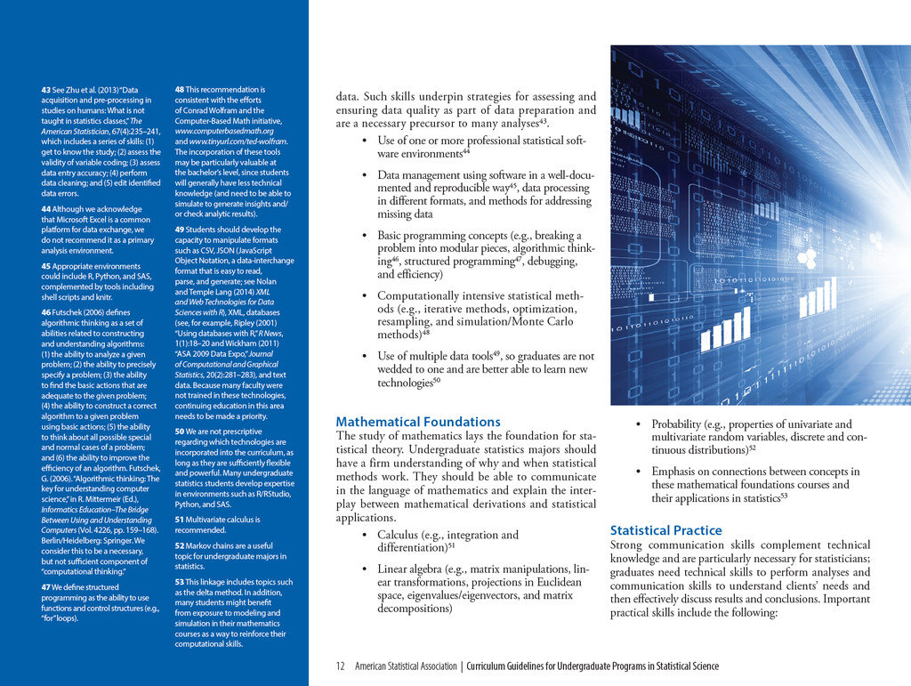

# Comprehensive Undergraduate Statistics Program (CUSP) Assessment Strategy

- ASA Guidelines cite 95 competencies aligned to 6 major topics
- Single assessment tool unlikely to match breadth & depth
- Two assessment tools piloted (so far?)
  - CUSP Survey
  - CUSP Test

| # Competencies | Topic area |
| --- | --- |
| 37 | Statistical Methods & Theory |
| 16 | Data Wrangling & Computing / Data Science |
| 11 | Mathematical Foundations |
| 18 | Statistical Practice |
| 9 | Problem Solving |
| 4 | Discipline-Specific Knowledge |

# Comprehensive Undergraduate Statistics Program (CUSP) Assessment

- Direct assessment
  - selected response test
  - approx. 1 hour duration
  - multiple institutions w. single cohort
  - single institution w. multiple cohorts
- Indirect assessment
  - survey data for students to self-report
  - several cohorts from single institution
- Penn State uses for CUSP Test
  - benchmarking student skills and competancies against ASA Guidelines
  - identify areas of need just prior to graduation
  - program evaluation data

# CUSP Survey

### Contribution

- Inventory of 95 competancies cited in the ASA Guidelines
- What do **students** feel they know & don’t know
- Benefits
  - 10-15 minutes to implement
  - Can be administered multiple times if desired
  - No problem including topics we don’t teach them
  - Also includes demographics
  - Easy implementation across institutions
- Risks/Issues
  - Reliability of self-reporting
  - Over/Underconfidence with content exposure
  - Lexical ambiguity (e.g., “Multivariate Methods”)

### Excerpt

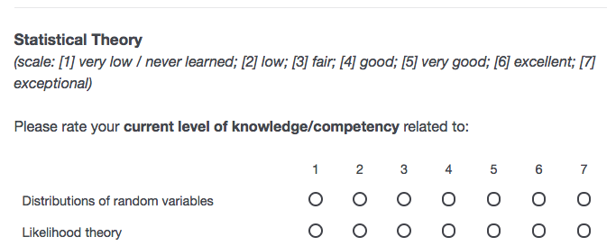

# CUSP Test

### Design

- Selected response assessment tool with broad coverage
- 33 tasks; some with multiple parts
  - 9 testlets
  - 24 conventional MC questions
- several tasks/subtasks assess multiple competancies
  - diminishing weight attributed to successive competancies (1, 1/2, 1/4, …)
  - 86 points possible
- Mix of original tasks & some from established instruments (used with permission)
  - 2 from the REGRESS assessment[^2]
  - 9 from the CAOS assessment[^3]

### Excerpt (partial item)

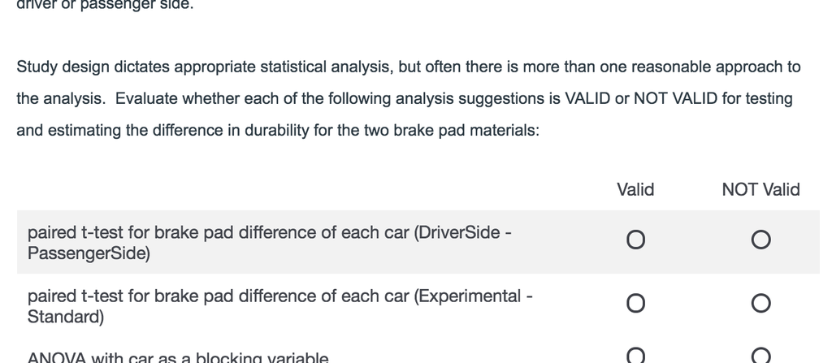

# CUSP Test

- Benefits
  - test statistical “reflexes” of students
  - built-in “CAOS” subtest
  - objective measure of student competancies
    - for individual students
    - for a class of students
    - aggregate useful for program evaluation
  - Easy implementation across institutions
- Risks/Issues
  - Scope constrained by test fatigue
  - Includes topics we don’t necessarily teach
  - Longer to implement
  - Variable use conditions jeopardize comparisons

# Preliminary Item Functioning Analysis

- Benchmarks for item statistics[^4]
  - Unidimensionality assumed by most current methods in use for assessment evaluation
  - Cronbach alpha (reliability)
  - descrimination > 0.15 preferred
  - 0.6 < proportion correct < 0.9
- Results
  - Principle components analysis supports unidimensionality
  - Cronbach alpha = 0.81
  - 30/33 items with discrimination > 0.15
  - 9/33 items in recommended difficulty range
  - 21/33 items with > 50% correct

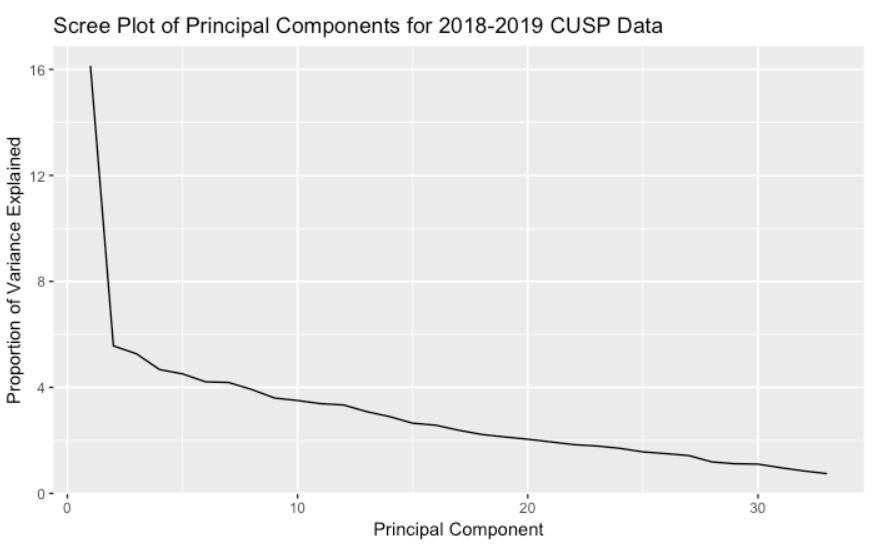

# Item discrimination

### Poor item discrimination

- One item was quite wordy and perhaps should be rewritten (also very difficult)
- Another was too difficult (3.6% correct)
- A third was a CAOS task about confidence interval interpretation

### Most discriminating items

- Probability distributions task (discrim = 0.59)
- Histograms & std deviation task (discrim = 0.50)
- OLS regression assumptions task (discrim = 0.46)

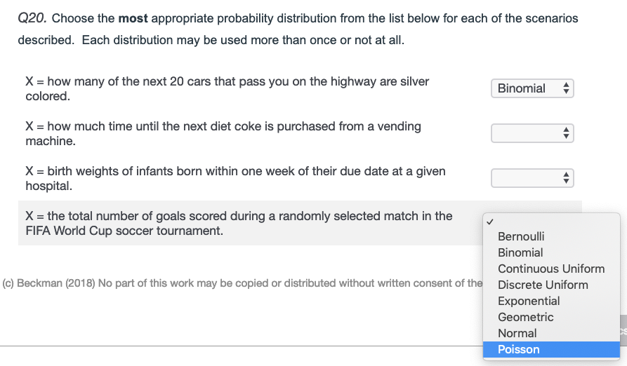

# Future work

### Shorter term

- Survey includes demographic information that can be linked to Test
- Opportunity to evaluate outcomes for different subpopulations of students
- Analysis of scoring weights & other considerations

### Longer term

- Further experimentation with test delivery (short, long)
- Alternative or additional tools for better/more complete alignment

[figure not shown]

# Backup slides

### CUSP Test blueprint alignment to ASA Guidelines

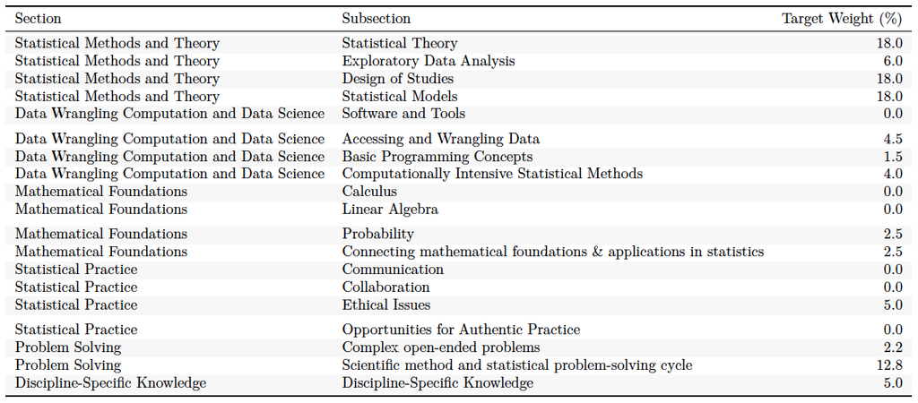

# Student Results (Demo)

- Students get one page front/back
- Front page explains more about the assessment, blueprint, etc (nothing personal)
- Automated personal summary on back
  - summary statistics for the institution
  - summary card of personal results

[figure not shown]

[^1]: American Statistical Association Undergraduate Guidelines Workgroup (2014). 2014 Curriculum guidelines for undergraduate programs in statistical science. Alexandria, VA: American Statistical Association. http://www.amstat.org/education/curriculumguidelines.cfm
[^2]: Enders, F. (2013). Do clinical and translational science graduate students understand linear regression? Development and early validation of the REGRESS quiz. *Clinical and Translational Science, 6*(6). p. 444-451.
[^3]: delMas, R., Garfield, J., Ooms, A., Chance, B. (2007). Assessing students’ conceptual understanding after a first course in statistics. *Statistics Education Research Journal, 6*. p. 28-58.
[^4]: Haladyna, T. M., & Rodriguez, M. C. (2013). *Developing and validating test items*. Routledge: New York.